# Sensitivity Analysis of Atmospheric Conductance

Alessandra Vidal Meza, Kiran Favre

2023-05-09

## Objective

For a given forest, you will perform a sensitivity analysis of model predictions of conductance. Atmospheric conductance refers to how easily vapor diffuses from vegetation surfaces.

Consider the sensitivity of your estimate to uncertainty in the following parameters and inputs: - $h$ is vegetation height (cm) - $k_d$ is a parameter; default 0.7 - $k_0$ is a parameter; default 0.1 - $v$ is windspeed (cm/s)

### Assumptions

- Assume windspeed, $v$, is normally distributed with a mean of 250 cm/s; a standard deviation of 30 cm/s
- Assume vegetation height, $h$, is somewhere between 9.5 and 10.5 m (but any value in that range is equally likely)
- Assume the $k_d$ and $k_0$ are normally distributed; standard deviation of 1% of their default values

## Latin Hypercube Sampling

Let’s use the Latin hypercube approach to generate parameter values for the parameters and inputs:

```r
# Define parameters and inputs
par_names <- c("v", "height", "k_o", "k_d")

# Extract number of parameters and inputs
n_par <- length(par_names)

# Set number of samples
n_sample <- 100

# Create a matrix with random samples
par_quant <- randomLHS(n_sample, n_par)

# Assign parameter and input names
colnames(par_quant) <- par_names

# Create a data frame of parameters and inputs
par_df <- as.data.frame(matrix(nrow = nrow(par_quant), ncol = ncol(par_quant)))

# Assign parameter and input names
colnames(par_df) <- par_names

# Set value for 1% standard deviation
pvar <- 100

## Normal Distribution
# Set parameter sampling to mean and sd given
par_df[,"v"] <- qnorm(par_quant[,"v"], mean = 250, sd = 30)
par_df[,"k_d"] <- qnorm(par_quant[,"k_d"], mean = 0.7, sd = 0.7/pvar)
par_df[,"k_o"] <- qnorm(par_quant[,"k_o"], mean = 0.1, sd = 0.1/pvar)

## Uniform Distribution
# Set height sampling to min and max given
par_df[,"height"] <- qunif(par_quant[,"height"], min = 9.5, max = 10.5)
```

## Atmospheric Conductance Model

Let’s now run the atmospheric conductance model for these parameters and inputs:

```r
# Use pmap() to run Catm() for all samples in par_df
ca_outputs <- pmap(par_df, Catm)

# Convert results list into array
output_array <- unlist(ca_outputs)

# Add results array to par_df
par_outputs <- par_df %>%
  mutate(output = output_array)
```

## Plots

Let’s plot conductance estimates in a way that accounts for parameter uncertainty:

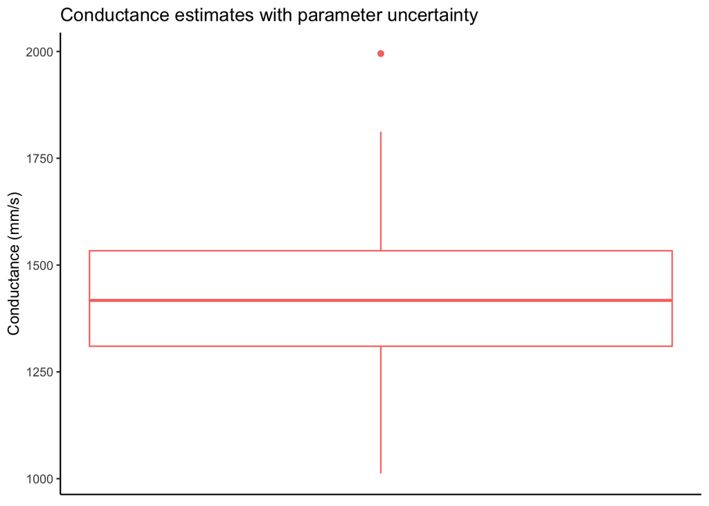

```r
# Wrangle data for visualization
par_outputs_long <- par_outputs %>%
  pivot_longer(cols = !output, # Select all columns except output
               names_to = "parm", # Pivot column names to param column
               values_to = "parmvalue") %>% # Pivot rows to parmvalue column
  mutate(output = as.numeric(output), # Convert to numeric
         parm = as.factor(parm), # Convert to factor
         parmvalue = as.numeric(parmvalue)) # Convert to numeric

# Plot conductance estimates around parameter uncertainty
ggplot(par_outputs_long, aes(y = output)) +
  geom_boxplot(show.legend = FALSE, aes(col = "#fb5607")) +
  labs(y = "Conductance (mm/s)",
       title = "Conductance estimates with parameter uncertainty") +
  theme_classic() +
  theme(axis.title.x = element_blank(),
        axis.ticks.x = element_blank(),
        axis.text.x = element_blank())
```

### Parameter Sensitivity

Next, plot conductance estimates against each of your parameters:

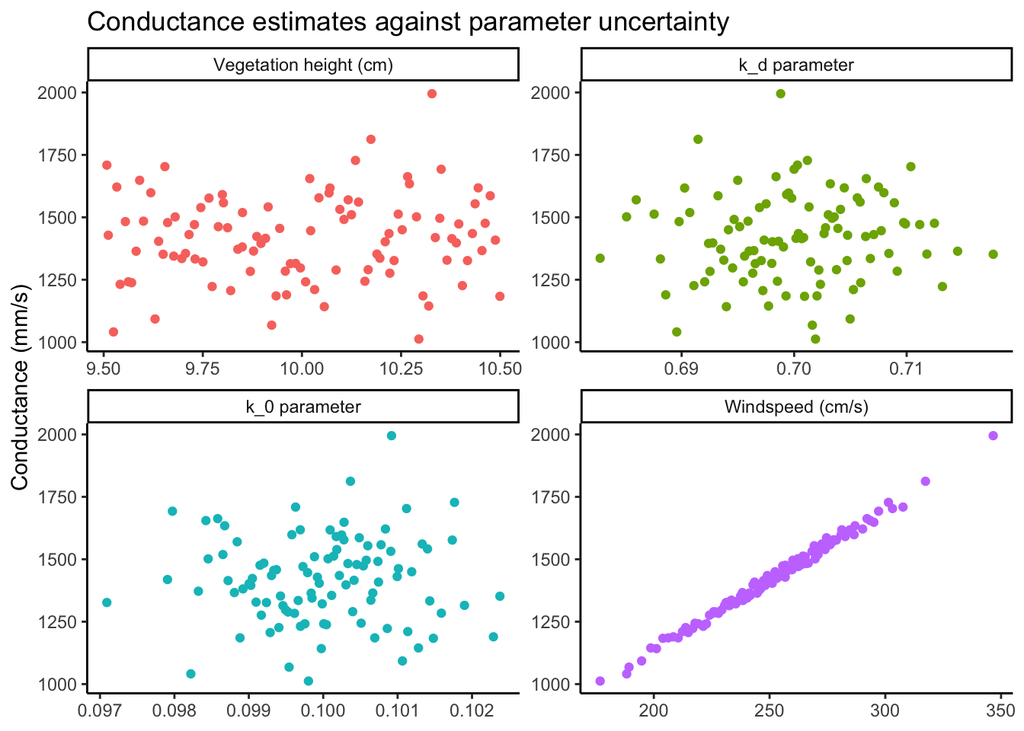

```r
# Plot conductance estimates against each parameters
ggplot(par_outputs_long, aes(parmvalue, output, col = parm)) +
  geom_point(show.legend = FALSE) +
  facet_wrap(~parm, scales = "free", ncol = 2,
             labeller = labeller(parm = c("height" = "Vegetation height (cm)",
                                          "k_d" = "k_d parameter",
                                          "k_o" = "k_0 parameter",
                                          "v" = "Windspeed (cm/s)"))) +
  labs(y = "Conductance (mm/s)",
       title = "Conductance estimates against parameter uncertainty") +
  theme_classic() +
  theme(axis.title.x = element_blank())
```

## Quantify Sensitivity

Let’s estimate the Partial Rank Correlation Coefficients:

```r
# Apply pcc() for partial rank correlation coefficients
senresult_rank <- pcc(par_df, par_outputs$output, rank = TRUE)

# View partial rank correlation coefficients results
senresult_rank$PRCC
```

```
##           original
## v       0.99850579
## height  0.80917247
## k_o     0.38212373
## k_d    -0.04772123
```

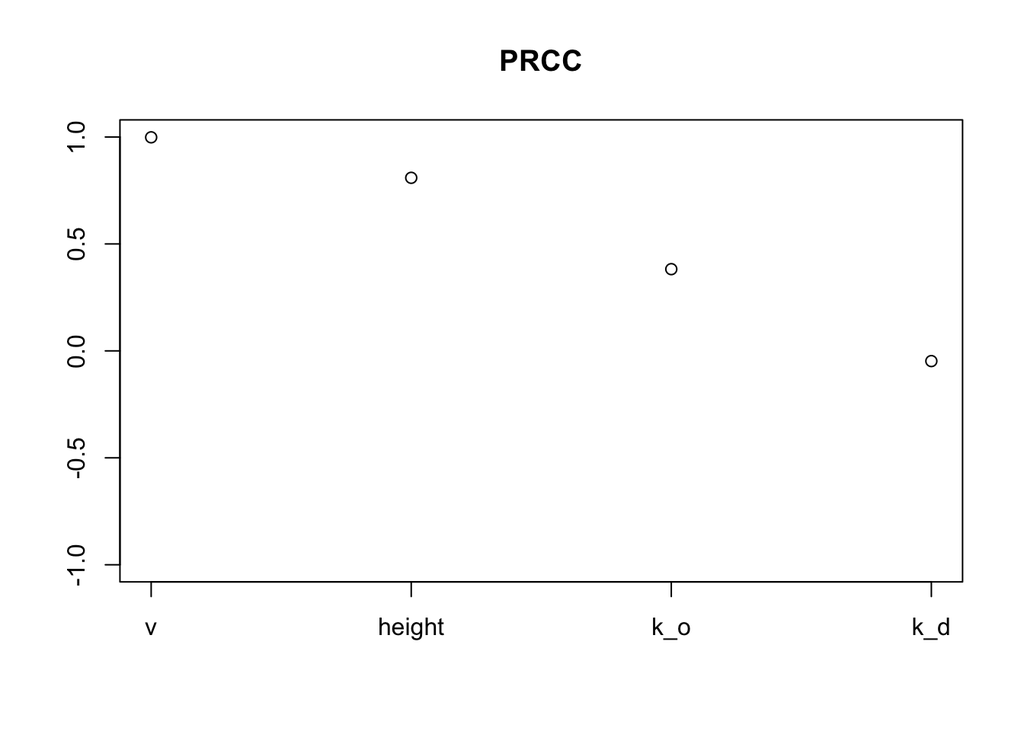

```r
# Plot partial rank correlation coefficients results
plot(senresult_rank)
```

## Discussion

**What do your results tell you about how aerodynamic conductance? What does it suggest about what you should focus on if you want to reduce uncertainty in aerodynamic conductance estimates? Does this tell you anything about the sensitivity of plant water use to climate change?** Aerodynamic conductance is most sensitive to the inputs windspeed, $v$, which is normally distributed, and vegetation height, $height$, which is uniform distributed. We can improve uncertainty in aerodynamic conductance estimates by focusing on either input. This is a consideration for climate change since wind speed will vary with regional and seasonal variability and plant water use is especially sensitive.